# Project3_Fenghua_Dong_Hang_Liao

Fenghua Dong & Hang Liao

2022-07-28

# 1 Introduction

This project is to perform risk analysis for the Nasdaq-100 Index. It will try volatility modeling, bootstrap, and Monte-Carlo simulation using methods introduced in class.

# 2 Question 2

## 2.1 Question 2A

We notice that the line plot of daily log returns of the NASDAQ100 is centered about 0. We also notice that there is far more variability after during times of economic uncertainty (e.g., great recession and covid 19 financial crisis)

```r
# Read in data
nasdaq_raw <- read_csv("NASDAQ100.csv")
# Calculate log returns for NASDAQ100
nasdaq_clean <- nasdaq_raw %>%
  rename(close_price = NASDAQ100) %>%
  dplyr::arrange(DATE) %>%
  mutate(
    date = as.Date(DATE),
    close_price =  as.numeric(close_price),
    # Take the daily log return
    daily_ret = log(close_price/lag(close_price))
  ) %>%
  filter(
   !is.na(daily_ret)
  )
```

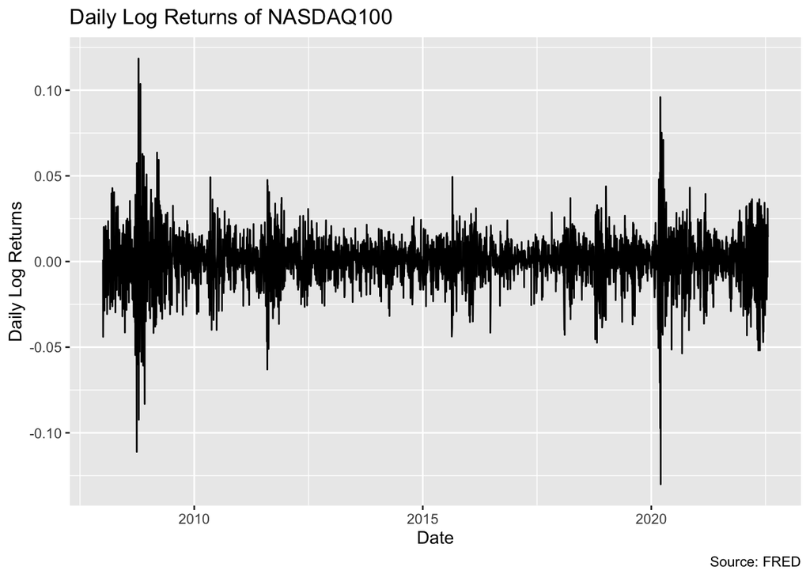

```r
# Plot daily log returns
p1 <- ggplot(nasdaq_clean, aes(x = date, y = daily_ret)) +
  geom_line() +
  labs(
    x = "Date",
    y = "Daily Log Returns",
    title = "Daily Log Returns of NASDAQ100",
    caption = "Source: FRED"
  )

p1
```

## 2.2 Question 2B

We notice the histogram of daily log returns does indeed look normal. We will use a QQ plot to test whether or not it follows a normal distribution.

The QQ plot suggests that log returns of the NASDAQ100 do not closely follow a normal distribution because the data have more extreme values than would be expected from a normal distribution.

Similarly the p-value returned from the Jaque Bera test indicates we reject the null hypothesis that the data is normally distributed.

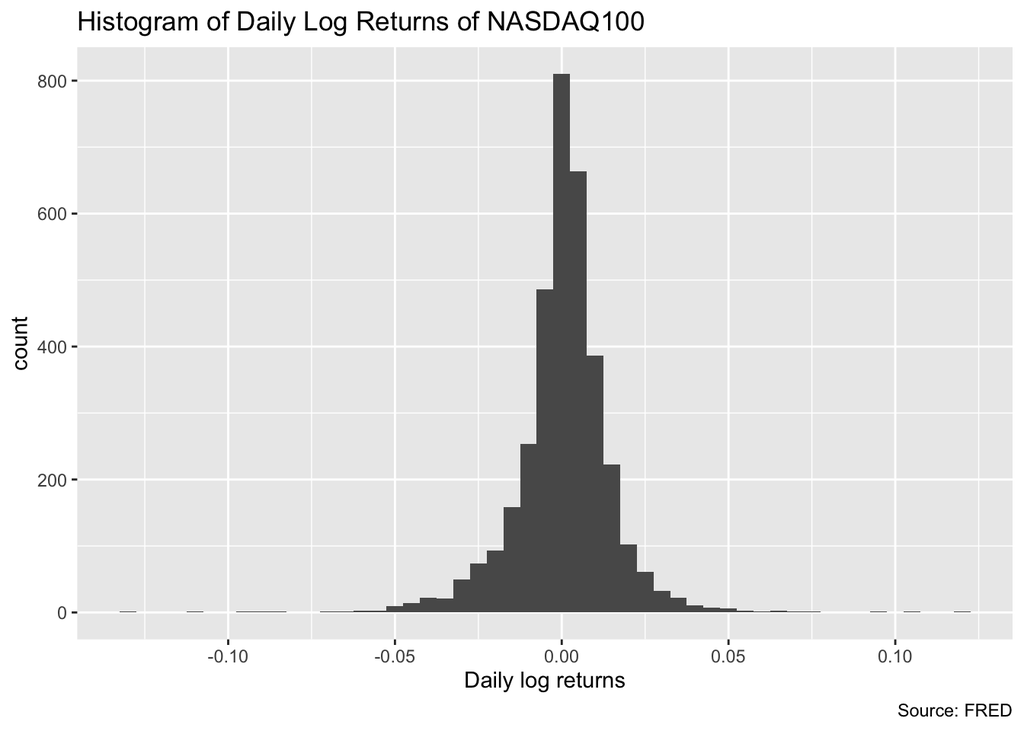

```r
# Plot histogram of daily log returns
p2 <- ggplot(nasdaq_clean, aes(x = daily_ret)) +
  geom_histogram(binwidth = .005) +
  labs(
    x = "Daily log returns",
    title = "Histogram of Daily Log Returns of NASDAQ100",
    caption = "Source: FRED"
  )

p2
```

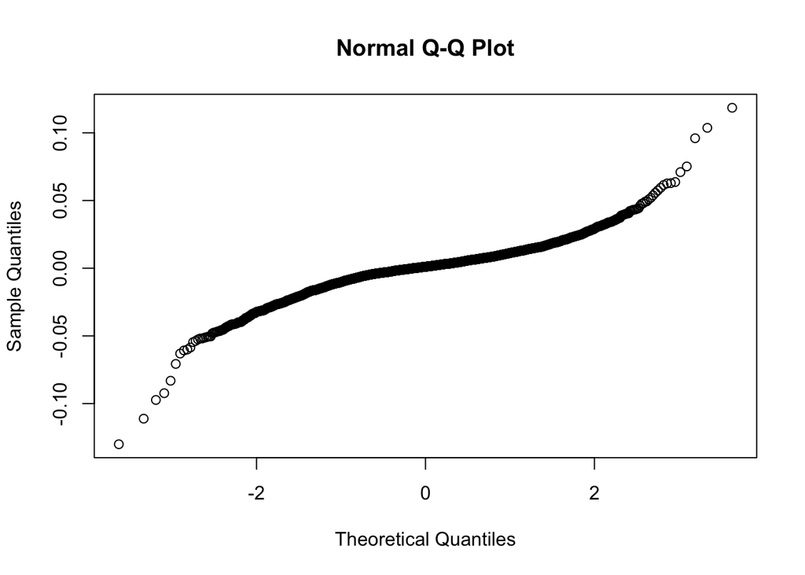

```r
# Produce QQ plot of NASDAQ log change
qqnorm(nasdaq_clean$daily_ret)
```

```r
# Jarque Bera test
# null hypothesis: the data is normally distributed
# alternative hypothesis: the data is not normally distributed
jarque.bera.test(nasdaq_clean$daily_ret)
```

```
##
##  Jarque Bera Test
##
## data:  nasdaq_clean$daily_ret
## X-squared = 10513, df = 2, p-value < 2.2e-16
```

# 3 Question 3

## 3.1 Question 3A - 3C

Demonstrated in code

```r
# Calculate daily returns for NASDAQ 100
nasdaq_clean <- nasdaq_raw %>%
  rename(close_price = NASDAQ100) %>%
  mutate(
    date = as.Date(DATE),
    close_price =  as.numeric(close_price),
    # Take the daily log return
    daily_ret = log(close_price/lag(close_price))
  ) %>%
  filter(
    date >= as.Date("2021-07-01") &
    date <= as.Date("2021-12-31")
  ) %>%
  filter(
    !is.na(daily_ret)
  )
#the datarame stores the 1% VaR
VaR_df <- tibble(
  id = NA, VaR = NA
)

for(i in 1:1000){

  # Sample NASDAQ
  nasdaq_sample <- nasdaq_clean %>%
    # Sample 200 rows with replacement
    sample_n(200, replace = T) %>%
    mutate(
      # Percent returns
      VaR = daily_ret * 100,
      # Create sample id
      id = i
    ) %>%
    arrange(VaR) %>%
    # Filter for second row (99% confidence interval)
    filter(row_number() == 2) %>%
    select(id, VaR)

  # Add one row (1% VaR) for each iteration
  VaR_df <- bind_rows(VaR_df, nasdaq_sample)
}

# Remove first row (NA row)
VaR_df <- VaR_df %>%
  filter(!is.na(VaR))

# Calculate mean an interquartile range
summary(VaR_df)
```

```
##        id              VaR
##  Min.   :   1.0   Min.   :-2.899
##  1st Qu.: 250.8   1st Qu.:-2.899
##  Median : 500.5   Median :-2.648
##  Mean   : 500.5   Mean   :-2.686
##  3rd Qu.: 750.2   3rd Qu.:-2.648
##  Max.   :1000.0   Max.   :-1.619
```

```r
# Calculate standard deviation
sd(VaR_df$VaR, na.rm = T)
```

```
## [1] 0.2712257
```

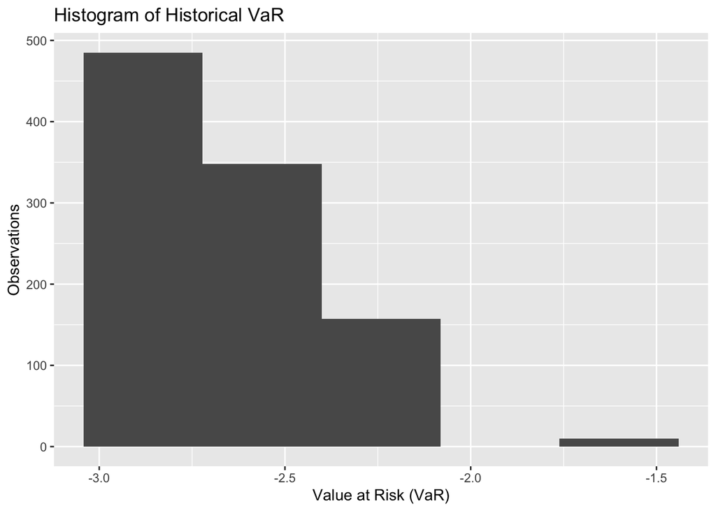

```r
# Plot histogram of 1% VaR estimates
p3 <- ggplot(VaR_df, aes(x = VaR)) +
  geom_histogram(bins = 5) +
  labs(
    x = "Value at Risk (VaR)",
    y = "Observations",
    title = "Histogram of Historical VaR "
  )

p3
```

## 3.2 Question 3D

We calculated the historical/bootstrap 1% VaR estimate. We found that the 1% VaR of the NASDAQ over this period was 2.685%. The interquartile range is .251%. The standard deviation was 0.272%.

# 4 Question 4

## 4.1 Question 4A - 4D

Demonstrated in code

```r
nasdaq_clean <- nasdaq_raw %>%
  rename(close_price = NASDAQ100) %>%
  mutate(
    date = as.Date(DATE),
    close_price =  as.numeric(close_price),
    # Take the daily log return
    daily_ret = log(close_price/lag(close_price)),
    VaR = daily_ret * 100
  ) %>%
  filter(
    date >= as.Date("2021-07-01") &
    date <= as.Date("2021-12-31")
  ) %>%
  filter(
    !is.na(daily_ret)
  )
nasdaq_mean <- mean(nasdaq_clean$VaR)
nasdaq_sd <- sd(nasdaq_clean$VaR)

VaR_MonteCarlo_df <- tibble(
  id = NA,
  VaR = NA
)

# repeat 1000 times
for(i in 1:1000){

  VaR_sample <- tibble(
      # Use mean and sd of daily log returns over last 6 months to construct normal
      # distribution. Sample 200 from distribution
      VaR = rnorm(200, mean = nasdaq_mean, sd = nasdaq_sd),
      id = i
    ) %>%
    arrange(VaR) %>%
    # Filter for 99% confidence internal
    filter(row_number() == 2)

  VaR_MonteCarlo_df <- bind_rows(VaR_MonteCarlo_df, VaR_sample)

}

# Remove missing values (NA row)
VaR_MonteCarlo_df <- VaR_MonteCarlo_df %>%
  filter(!is.na(VaR))

# Calculate mean an interquartile range
summary(VaR_MonteCarlo_df)
```

```
##        id              VaR
##  Min.   :   1.0   Min.   :-3.323
##  1st Qu.: 250.8   1st Qu.:-2.440
##  Median : 500.5   Median :-2.261
##  Mean   : 500.5   Mean   :-2.279
##  3rd Qu.: 750.2   3rd Qu.:-2.092
##  Max.   :1000.0   Max.   :-1.548
```

```r
# Calculate standard deviation
sd(VaR_MonteCarlo_df$VaR, na.rm = T)
```

```
## [1] 0.2679981
```

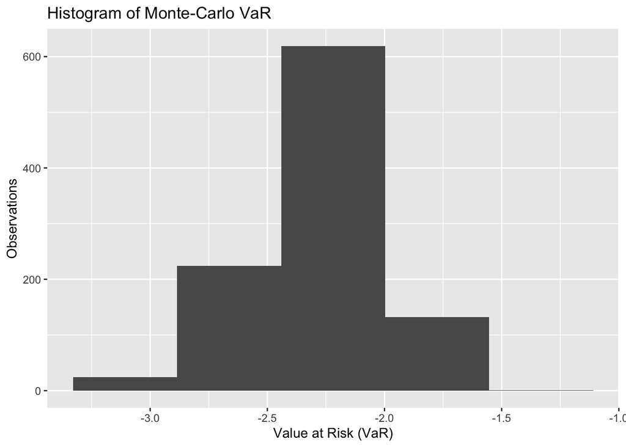

```r
# Plot histogram of 1% VaR estimates
p4 <- ggplot(VaR_MonteCarlo_df, aes(x = VaR)) +
  geom_histogram(bins = 5) +
  labs(
    x = "Value at Risk (VaR)",
    y = "Observations",
    title = "Histogram of Monte-Carlo VaR "
  )

p4
```